# Block 5: Normal or not? — Tower-year climate vs. WorldClim 1970–2000 normals

Author

Niklas Mönkemöller (student no. 18)

Published

November 25, 2026

## E1. Question and hypothesis

**Question:** Are the years observed at five FLUXNET towers climatologically “normal” — i.e., how far do tower-year mean temperature and total precipitation deviate from the 1970–2000 WorldClim normals at the tower locations?

**Hypothesis:** Tower-years are on average **warmer** than the 1970–2000 normal (because the observation years 2001–2025 lie after the normal period, during which climate warmed), and the **driest** towers (low WorldClim BIO12) show the **largest relative precipitation anomalies**, because in dry climates a given absolute precipitation change translates into a larger relative anomaly and interannual variability is higher.

**Why these five towers are a reasonable test:** the set spans a wide climatic gradient — tropical savanna (AU-Dry, BIO1 ≈ 27 °C), alpine meadow (CN-HaM, BIO1 ≈ −0.7 °C), temperate sites (CA-Ca2, FR-Hes) and an irrigated Mediterranean-agricultural site (US-Bi1) — with annual precipitation from ~400 to ~1600 mm. That spread is what the second part of the hypothesis (dry towers → larger relative anomalies) needs. It is a small, non-random sample (n = 5 towers), so the test is descriptive rather than inferential.

## E2. Data

### Provenance table

| Dataset | Variables used | Spatial resolution | Time resolution and period | Downloaded on | Script and changes | Citation |
| --- | --- | --- | --- | --- | --- | --- |
| FLUXNET (shuttle snapshot) | `TA_F`, `TA_F_QC`, `P_F`, `P_F_QC`, `P_ERA` (daily) | point (tower footprint ~100 m–1 km) | daily, 1997–2026 (site-specific) | 2026-11-13 (snapshot provided with the course) | `scripts/block5/09_merge.py` (provided; no changes) | Pastorello et al. (2020); site citations in E6 |
| WorldClim 2.1 | BIO1 (mean annual temp.), BIO12 (annual precip.), monthly tavg/prec normals | 5′ grid cells (~9 km at the equator) | monthly normals, 1970–2000 | 2026-11-25 | `scripts/block5/02_worldclim.py` (provided; no changes) | Fick & Hijmans (2017) |
| SoilGrids 2.0 | clay, sand (0–30 cm mean) | 250 m grid cells | static (2017 snapshot of 1950–2017 data) | 2026-11-25 | `scripts/block5/04_soilgrids.py` (provided; no changes) | Poggio et al. (2021) |

### The two datasets at the five towers

WorldClim BIO1/BIO12 and SoilGrids clay/sand (0–30 cm) per tower, together with the tower-observed means over the FLUXNET years:

| site_id | n | TA | P | BIO1 | BIO12 | clay | sand |
| --- | --- | --- | --- | --- | --- | --- | --- |
| AU-Dry | 17 | 27.2 | 831.1 | 26.8 | 849.0 | 27.1 | 64.0 |
| CA-Ca2 | 10 | 8.6 | 1156.3 | 8.6 | 1596.0 | 13.4 | 37.4 |
| CN-HaM | 14 | -1.0 | 3047.5 | -0.7 | 468.0 | 17.8 | 43.3 |
| FR-Hes | 25 | 10.7 | 916.1 | 9.5 | 780.0 | 26.9 | 22.0 |
| US-Bi1 | 9 | 14.8 | 385.3 | 15.5 | 396.0 | 30.0 | 11.1 |

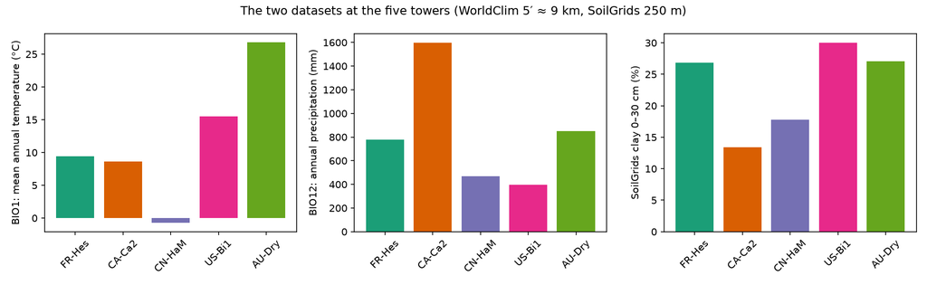

The two complementary datasets at the five towers: WorldClim BIO1 (mean annual temperature), BIO12 (annual precipitation) and SoilGrids clay content 0–30 cm. Note the broken CN-HaM precipitation in the FLUXNET product (~3 000 mm) vs. the WorldClim normal (468 mm) — see section E3.

## E3. Methods

**Download.** All scripts were provided with the course and run unchanged with `--student 18`, which selects my five towers (AU-Dry, CA-Ca2, CN-HaM, FR-Hes, US-Bi1) from `tower_sets_block4.csv`. `02_worldclim.py` downloads the WorldClim 2.1 5′ base rasters (bioclimatic variables plus monthly temperature and precipitation normals) and samples them at the tower coordinates. `04_soilgrids.py` reads the SoilGrids 2.0 Cloud-Optimised GeoTIFFs directly from the ISRIC server via per-property VRTs and samples the pixel under each tower. `09_merge.py` reads the FLUXNET daily (`DD`) files from the local snapshot zip. The analysis itself is in `scripts/block5/10_anomaly_analysis.ipynb`, a notebook I wrote (the three download/merge scripts above are unchanged); it produces `data/processed/block5_anomalies.csv` and the two figures. One problem surfaced during the analysis (not during download): the FLUXNET precipitation at CN-HaM is unusable — see below.

**Extraction.** WorldClim and SoilGrids are sampled at the single grid cell containing the tower coordinates (WGS 84 lat/lon; SoilGrids internally uses a custom equal-area CRS, handled by `pyproj` in the script). No window averaging was used — the assignment asks for the nearest cell, and the scale implications of that choice are discussed in E5.

**Processing.** FLUXNET daily values with the fill value −9999 are treated as missing. A tower-year is kept only if it has ≥ 300 **non-missing** daily `TA_F` values and starts in 2001 or later. The first condition drops FR-Hes 2026, which has 365 rows but only 234 measured days (the record ends on 6 September 2026) — summing precipitation over that partial year would give a spurious −49 % anomaly. The second condition drops 5 tower-years that lie inside the 1970–2000 normal period itself (FR-Hes 1997–2000 and CA-Ca2 2000), because a year that is part of the normal is not an independent test of it. 75 tower-years remain. Annual `TA_mean` is the mean of daily `TA_F`; annual `P_sum` the sum of daily `P_F`. WorldClim BIO1/BIO12 are used directly (°C, mm). SoilGrids values are converted from integer maps by the script’s d-factor (clay/sand in %, averaged over the 0–5, 5–15 and 15–30 cm depths to a 0–30 cm value). The three tables are joined on `site_id`.

**Data-quality check on precipitation.** Before computing anomalies I checked whether `P_F` is measured or model-derived. The check reads the raw FLUXNET daily files directly (the QC flags are not carried into `site_daily.csv`):

| site_id | P_F_QC | P_F == P_ERA | P_F (mm/yr) | TA_F_QC | BIO12 |
| --- | --- | --- | --- | --- | --- |
| CA-Ca2 | 0.95 | False | 1145.46 | 0.94 | 1596.0 |
| US-Bi1 | 0.89 | False | 385.25 | 0.92 | 396.0 |
| FR-Hes | 0.82 | False | 911.22 | 0.81 | 780.0 |
| CN-HaM | 0.00 | True | 3047.80 | 0.95 | 468.0 |
| AU-Dry | 0.70 | False | 831.09 | 0.77 | 849.0 |

**CN-HaM fails:** its `P_F` is identical to the ERA5-derived `P_ERA` on every day, `P_F_QC` is 0 everywhere (no measured contribution), and the resulting ~3 000 mm yr⁻¹ contradicts both the WorldClim normal (468 mm) and the published climate of the Haibei station on the north-eastern Tibetan Plateau (~500–600 mm yr⁻¹). The FLUXNET product’s ERA5 precipitation for this site is broken, so CN-HaM is **excluded from the precipitation anomaly** (dP_pct = NA) but kept for the temperature anomaly (its `TA_F` is 95% measured and matches BIO1 well).

**Analysis.** For each tower-year *y* at tower *s*:

$$dT_{s,y} = TA_{s,y} - BIO1_s \qquad dP_{s,y} = 100 \cdot \frac{P_{s,y} - BIO12_s}{BIO12_s}$$

## E4. Results

Across **75 tower-years** (2001–2025, 5 towers), the mean temperature anomaly is **dT = +0.35 K**; **47 of 75 tower-years (63 %)** were warmer than the 1970–2000 normal. Of the **61 tower-years with usable precipitation** (CN-HaM excluded), **32 (52 %)** were drier than normal.

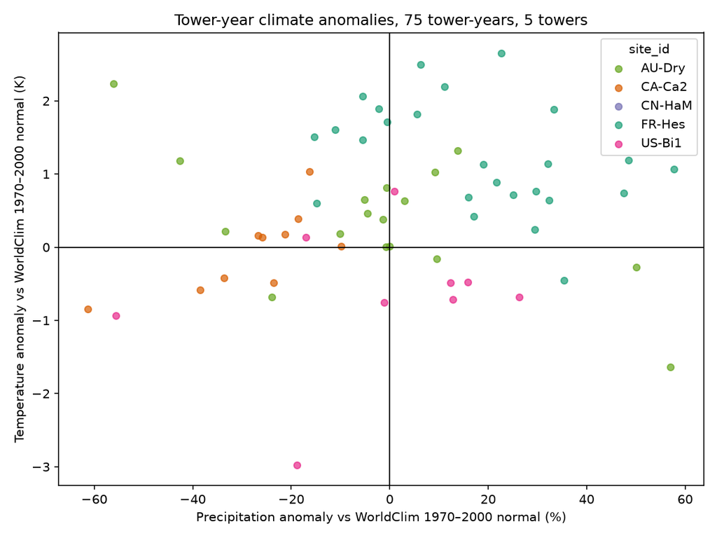

Per-site means:

| site_id | dP_pct | dT |
| --- | --- | --- |
| AU-Dry | -2.11 | 0.37 |
| CA-Ca2 | -27.55 | -0.04 |
| CN-HaM | NaN | -0.32 |
| FR-Hes | 17.45 | 1.24 |
| US-Bi1 | -2.69 | -0.68 |

The warming signal is dominated by **FR-Hes** (+1.24 K, 24 of 25 years warmer) and **AU-Dry** (+0.37 K, 13 of 17 warmer); **CA-Ca2** (−0.04 K), **CN-HaM** (−0.32 K) and **US-Bi1** (−0.68 K) are on average at or slightly below normal. For precipitation, **CA-Ca2** is strongly drier than normal (−28 %, all 10 years), while **FR-Hes** is wetter (+17 %) and AU-Dry and US-Bi1 are near normal (−2 % and −3 %).

## E5. Discussion

**Scale.** WorldClim cells are 5′ ≈ 9 km across — one to two orders of magnitude larger than a flux footprint (100 m–1 km). In complex terrain (CN-HaM on the Tibetan Plateau edge, CA-Ca2 in coastal British Columbia) the 9 km cell can differ substantially from the tower’s local climate, so part of the “anomaly” may be a scale mismatch rather than real interannual variability. SoilGrids at 250 m is much better matched to the footprint scale, so the soil values themselves are the more trustworthy of the two predictors — but the link between a static 0–30 cm clay/sand map and multi-year precipitation is physically weak, so the soil correlation is a description of the tower set, not an explanation of the anomalies.

**Limitations.** (1) The CN-HaM precipitation in the FLUXNET product is broken (fully ERA5-derived, ~3 000 mm yr⁻¹ vs. ~500–600 mm published), which cost one of five towers for the precipitation analysis and shows how sensitive the anomaly computation is to product quality control. (2) Confounding site effects: CA-Ca2 is a clearcut stand (harvested 1999/2000) whose local microclimate differs from the grid normal, and US-Bi1 is irrigated alfalfa, so its tower precipitation anomaly does not reflect water stress. With more time I would add more towers per climate zone so that the BIO12 and clay/sand comparisons rest on more than four points, and replace the broken ERA5-derived precipitation with a station or gauge-based product.

## E6. Data and citations

**FLUXNET site citations** (from the shuttle snapshot, `data/raw/CITATIONS.txt`):

- AU-Dry: Beringer, J., Hutley, L., Northwood, M. (2026): Dry River FLUXNET Release 2026_r1. Version 2026_r1. Terrestrial Ecosystem Research Network (TERN). (Dataset).
- CA-Ca2: T. Andrew Black (2025), AmeriFlux FLUXNET-1F CA-Ca2 British Columbia – Clearcut Douglas-fir stand (harvested winter 1999/2000), Ver. v1.3_r1 (2000–2010), AmeriFlux AMP, (Dataset). https://doi.org/10.17190/AMF/2007164
- CN-HaM: Du, M., Gu, S., Kato, T., Li, Y., Liang, Z., Zhang, F. (2026). Fluxnet Archive Product from Haibei Alpine Tibet site, 2001–2014, FLUXNET, https://hdl.handle.net/11676/eHxCM4Gfk3Wo-yA1sym5lBRo
- FR-Hes: Cuntz, M., Joetzjer, E., Aiguier, T., Courtois, P., Lily, J.-B., Naiken, A. (2026). Fluxnet Archive Product from Hesse, 1997-01-01–2026-09-06, FLUXNET, https://hdl.handle.net/11676/PiV4aacfudwGs03sWmiN7Inf
- US-Bi1: Rey-Sanchez, C., Wang, C. T., Szutu, D., Shortt, R., Chamberlain, S. D., Verfaillie, J., Baldocchi, D. (2025), AmeriFlux FLUXNET-1F US-Bi1 Bouldin Island Alfalfa, Ver. v1.3_r1 (2016–2024), AmeriFlux AMP, (Dataset). https://doi.org/10.17190/AMF/1871134

**Complementary datasets:**

- WorldClim 2.1: Fick, S. E., & Hijmans, R. J. (2017). WorldClim 2: new 1-km spatial resolution climate surfaces for global land areas. *International Journal of Climatology*, 37(12), 4302–4315. https://doi.org/10.1002/joc.5086
- SoilGrids 2.0: Poggio, L., de Sousa, L. M., Batjes, N. H., Heuvelink, G. B. M., Kempen, B., Ribeiro, E., & Rossiter, D. (2021). SoilGrids 2.0: producing soil information for the globe with quantified spatial uncertainty. *SOIL*, 7, 217–240. https://doi.org/10.5194/soil-7-217-2021

**FLUXNET product:** Pastorello, G., et al. (2020). The FLUXNET2015 dataset and the ONEFlux processing pipeline for eddy covariance data. *Scientific Data*, 7, 225. https://doi.org/10.1038/s41597-020-0534-3

**FLUXNET acknowledgement:**

> FLUXNET data products were produced and harmonized by eddy covariance regional networks and data processing centers, including AmeriFlux, ChinaFlux, European Fluxes Database, ICOS, JapanFlux, KoFlux, OzFlux, SAEON, and TERN. These products also include a modified version of ERA5 hourly data provided by the Copernicus Climate Change Service.